# Tarea 1

# Ejercicio 1

## En este ejercicio vamos a usar la tabla de datos SpotifyTop2018 40 V2.csv

## a) Calcule el resumen numerico, interprete los resultados para dos variables.

```python
import os
import pandas as pd
pasada = os.getcwd()
os.chdir("C:/Users/rzamoram/Documents/Machine Learning/Métodos NO Supervisados con Python/Clase 1")
os.getcwd()
ejemplo10 = pd.read_csv("SpotifyTop2018_40_V2.csv", decimal = ".", header = 0, index_col = 0)
print(ejemplo10.head())
datos = pd.DataFrame(ejemplo10)
```

```
                          danceability  energy  loudness  speechiness  \
Dura                             0.791   0.848    -3.456       0.0506
Plug_Walk                        0.876   0.519    -6.531       0.1430
Silence                          0.520   0.761    -3.093       0.0853
Solo_(feat._Demi_Lovato)         0.737   0.636    -4.546       0.0437
Sin_Pijama                       0.791   0.745    -3.695       0.0464

                          acousticness  instrumentalness  liveness  valence  \
Dura                            0.1830          0.000000     0.409    0.828
Plug_Walk                       0.2020          0.000000     0.108    0.158
Silence                         0.2560          0.000005     0.170    0.286
Solo_(feat._Demi_Lovato)        0.0441          0.000067     0.350    0.565
Sin_Pijama                      0.3540          0.000029     0.104    0.820

                            tempo  duration_ms  time_signature
Dura                       95.000       200480               4
Plug_Walk                  94.981       175230               4
Silence                   141.971       180823               4
Solo_(feat._Demi_Lovato)  105.005       222653               4
Sin_Pijama                 94.014       188560               4
```

```python
print(datos.dropna().describe())
```

```
       danceability     energy   loudness  speechiness  acousticness  \
count     40.000000  40.000000  40.000000    40.000000     40.000000
mean       0.719200   0.661925  -5.846250     0.121292      0.184621
std        0.151423   0.137874   1.611051     0.094732      0.209052
min        0.258000   0.391000  -9.211000     0.023200      0.000282
25%        0.680500   0.564250  -7.077000     0.049550      0.030800
50%        0.750000   0.659000  -5.930000     0.105500      0.121500
75%        0.817500   0.772500  -4.624000     0.144500      0.227500
max        0.922000   0.909000  -3.093000     0.516000      0.847000

       instrumentalness   liveness    valence       tempo    duration_ms  \
count         40.000000  40.000000  40.000000   40.000000      40.000000
mean           0.003695   0.177125   0.467942  122.108850  205645.700000
std            0.021231   0.130476   0.228504   31.178064   34324.034325
min            0.000000   0.021500   0.096700   77.169000   95467.000000
25%            0.000000   0.095275   0.287500   95.037500  189856.000000
50%            0.000003   0.112000   0.437500  122.531500  212904.500000
75%            0.000043   0.294750   0.633250  140.585750  226983.250000
max            0.134000   0.552000   0.931000  191.702000  268867.000000

       time_signature
count       40.000000
mean         3.950000
std          0.220721
min          3.000000
25%          4.000000
50%          4.000000
75%          4.000000
max          4.000000
```

```python
print(datos.describe())
```

```
       danceability     energy   loudness  speechiness  acousticness  \
count     40.000000  40.000000  40.000000    40.000000     40.000000
mean       0.719200   0.661925  -5.846250     0.121292      0.184621
std        0.151423   0.137874   1.611051     0.094732      0.209052
min        0.258000   0.391000  -9.211000     0.023200      0.000282
25%        0.680500   0.564250  -7.077000     0.049550      0.030800
50%        0.750000   0.659000  -5.930000     0.105500      0.121500
75%        0.817500   0.772500  -4.624000     0.144500      0.227500
max        0.922000   0.909000  -3.093000     0.516000      0.847000

       instrumentalness   liveness    valence       tempo    duration_ms  \
count         40.000000  40.000000  40.000000   40.000000      40.000000
mean           0.003695   0.177125   0.467942  122.108850  205645.700000
std            0.021231   0.130476   0.228504   31.178064   34324.034325
min            0.000000   0.021500   0.096700   77.169000   95467.000000
25%            0.000000   0.095275   0.287500   95.037500  189856.000000
50%            0.000003   0.112000   0.437500  122.531500  212904.500000
75%            0.000043   0.294750   0.633250  140.585750  226983.250000
max            0.134000   0.552000   0.931000  191.702000  268867.000000

       time_signature
count       40.000000
mean         3.950000
std          0.220721
min          3.000000
25%          4.000000
50%          4.000000
75%          4.000000
max          4.000000
```

```python
print(datos.mean(numeric_only=True))
```

```
danceability             0.719200
energy                   0.661925
loudness                -5.846250
speechiness              0.121292
acousticness             0.184621
instrumentalness         0.003695
liveness                 0.177125
valence                  0.467942
tempo                  122.108850
duration_ms         205645.700000
time_signature           3.950000
dtype: float64
```

```python
print(datos.std(numeric_only=True))
```

```
danceability            0.151423
energy                  0.137874
loudness                1.611051
speechiness             0.094732
acousticness            0.209052
instrumentalness        0.021231
liveness                0.130476
valence                 0.228504
tempo                  31.178064
duration_ms         34324.034325
time_signature          0.220721
dtype: float64
```

```python
print(datos.max(numeric_only=True))
```

```
danceability             0.922
energy                   0.909
loudness                -3.093
speechiness              0.516
acousticness             0.847
instrumentalness         0.134
liveness                 0.552
valence                  0.931
tempo                  191.702
duration_ms         268867.000
time_signature           4.000
dtype: float64
```

### En este caso analizando danceability y energy, en este caso al ser ambas variables de 0 a 1, con un 0,719 y 0,662, indican que en promedio las canciones mas reproducidas en Spotify del 2018, son aptas y tienen intensidad y actividad la desviacion estandar de 0,151 y 0,138, indica una desviacion de estas dos variables no tan amplia. El maximo de 0,922 y 0,909 indica que no existe cancion en 10 es decir, completamente apta para bailar, ni medida de intensidad y actividad total

## b) Realice el test de normalidad para una variable e interprete el resultado.

```
(0.968994140625, 0.33429256081581116)
0.33429256081581116
Sí sigue la curva Normal (No se rechaza H0)
```

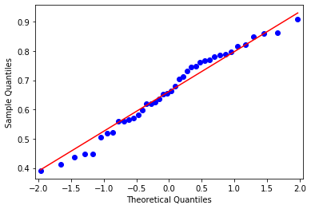

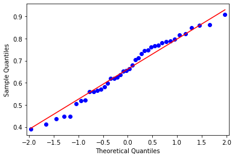

```python
import scipy.stats
#import numpy as np
shapiro_resultados = scipy.stats.shapiro(datos.energy)
print(shapiro_resultados)
p_value = shapiro_resultados[1]
print(p_value)

alpha = 0.05
if p_value > alpha:
	print('Sí sigue la curva Normal (No se rechaza H0)')
else:
	print('No sigue la curva Normal (Se rechaza H0)')

from statsmodels.graphics.gofplots import qqplot
#from matplotlib import pyplot
qqplot(datos.energy, line='s')
```

```python
ks_resultados = scipy.stats.kstest(datos.energy, cdf='norm')
print(ks_resultados)
p_value = ks_resultados[1]
print(p_value)
# interpretación
alpha = 0.05
if p_value > alpha:
	print('Sí sigue la curva Normal (No se rechaza H0)')
else:
	print('No sigue la curva Normal (Se rechaza H0)')
```

```
KstestResult(statistic=0.6521013820709639, pvalue=3.6594313320286536e-17)
3.6594313320286536e-17
No sigue la curva Normal (Se rechaza H0)
```

### Aqui resulta interesante notar que el test de Shapiro-Wilk no rechaza la hipotesis nula y el de Kolmogrov-Smirnov. Luego de una breve investigacion resulta importante notar que las estimaciones de muestra mas pequenas generan mejores estimaciones en Shapiro por lo que resulta mejor tomar en cuenta esta prueba, ya que la prueba de Kolmogrov tiende a castigar mas en la estimacion de muestras pequenas, por lo que, es se toma la Shapiro y se asume que la distribucion de la variable de energia es normal

## c) Realice un grafico de dispersion e interprete dos similitudes en el grafico.

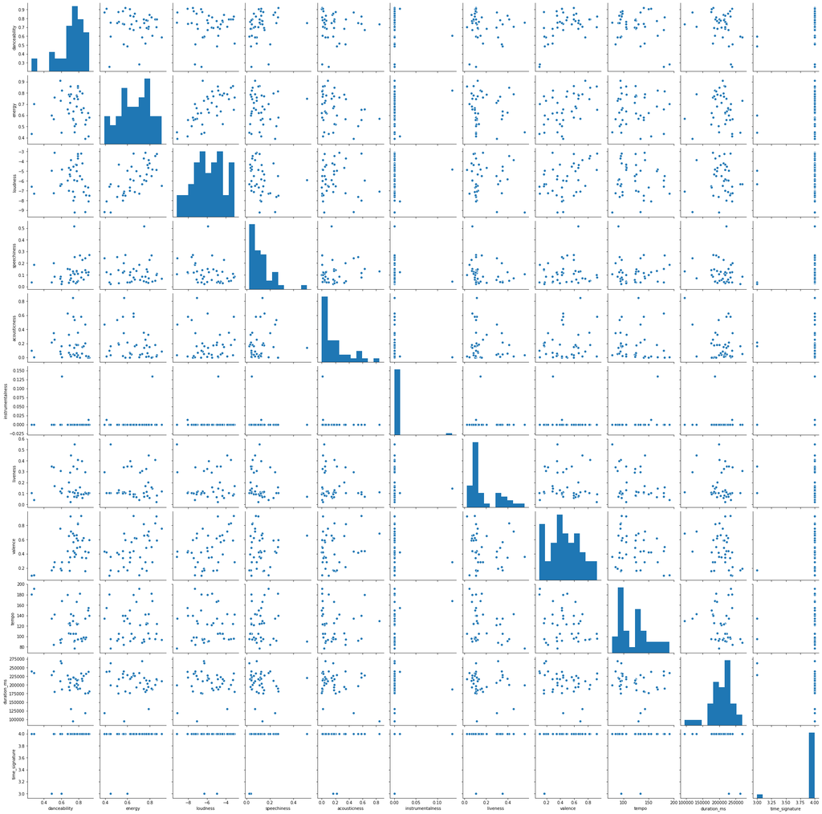

```python
import seaborn as sns
#import matplotlib.pyplot as plt

sns.pairplot(datos, size=2.5)
```

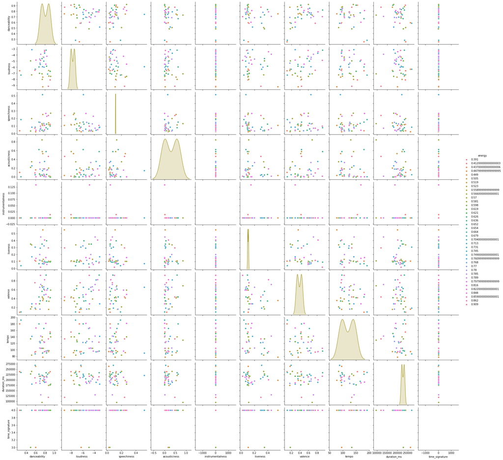

```python
import seaborn as sns
sns.pairplot(datos, hue='energy', size=2.5)
```

## d) Para dos variables identifique los datos atıpicos, si los hay.

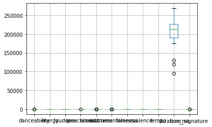

```python
boxplots = datos.boxplot(return_type='axes')
```

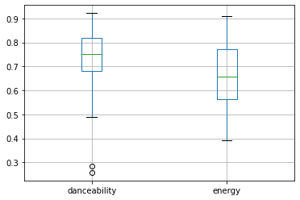

```python
boxplots = datos[['danceability','energy']].boxplot(return_type='axes')
```

### El boxplot con todas las variables resulta complicado de interpretar, especialmente al haber una variable con datos muy dispersos al delimiatrlo a dos variables(danceability y energia) se muestra que existen dos datos atipicos bajos en danceability en energia no hay

## e) Calcule la matriz de correlaciones

```python
corr = datos.corr()
print(corr)
```

```
                  danceability    energy  loudness  speechiness  acousticness  \
danceability          1.000000 -0.052973 -0.043320     0.207397      0.016291
energy               -0.052973  1.000000  0.665634    -0.035225     -0.269420
loudness             -0.043320  0.665634  1.000000    -0.281621     -0.081194
speechiness           0.207397 -0.035225 -0.281621     1.000000      0.097140
acousticness          0.016291 -0.269420 -0.081194     0.097140      1.000000
instrumentalness     -0.102198  0.159487  0.079780    -0.131971     -0.150742
liveness             -0.031392 -0.082066 -0.050145    -0.225592     -0.155930
valence               0.470648  0.465742  0.402273     0.059612      0.174967
tempo                -0.301067  0.005003 -0.034438     0.018453     -0.064332
duration_ms          -0.305303 -0.035215  0.011911    -0.144740     -0.297226
time_signature        0.268821  0.234110 -0.032557     0.224884     -0.006534

                  instrumentalness  liveness   valence     tempo  duration_ms  \
danceability             -0.102198 -0.031392  0.470648 -0.301067    -0.305303
energy                    0.159487 -0.082066  0.465742  0.005003    -0.035215
loudness                  0.079780 -0.050145  0.402273 -0.034438     0.011911
speechiness              -0.131971 -0.225592  0.059612  0.018453    -0.144740
acousticness             -0.150742 -0.155930  0.174967 -0.064332    -0.297226
instrumentalness          1.000000 -0.046094 -0.130534  0.254822    -0.072171
liveness                 -0.046094  1.000000 -0.108392 -0.281270    -0.115850
valence                  -0.130534 -0.108392  1.000000 -0.240702    -0.273304
tempo                     0.254822 -0.281270 -0.240702  1.000000    -0.174676
duration_ms              -0.072171 -0.115850 -0.273304 -0.174676     1.000000
time_signature            0.040438 -0.090593  0.302942  0.056347    -0.272389

                  time_signature
danceability            0.268821
energy                  0.234110
loudness               -0.032557
speechiness             0.224884
acousticness           -0.006534
instrumentalness        0.040438
liveness               -0.090593
valence                 0.302942
tempo                   0.056347
duration_ms            -0.272389
time_signature          1.000000
```

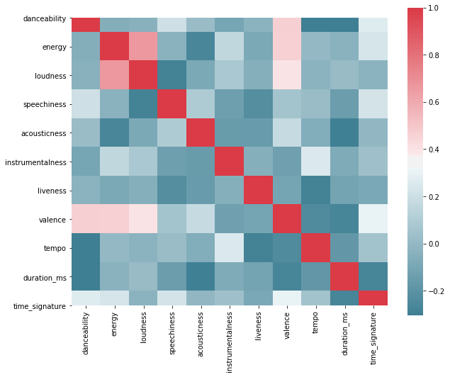

```python
import matplotlib.pyplot as plt
import numpy as np
import seaborn as sns
f, ax = plt.subplots(figsize=(10, 8))
sns.heatmap(corr, mask=np.zeros_like(corr, dtype=np.bool), cmap=sns.diverging_palette(220, 10, as_cmap=True), square=True, ax=ax)
```

### La matriz de correlaciones indica el nivel de relacion que existe entre las variables de un problema. Entre mas correlacionadas estan mas similar resulta su comportamiento dentro del problema. Aqui debe notarse que entre mayor sea su nivel de correlacion mas parecido sera su comportamiento. Entre mas negativo sea resulta mas opuesto su comportamiento. La gran correlacion puede indicar tambien redundancia o agrupacion de variables. En este caso parece que la mayoria de las variables estan inversamente correlacionadas. Y el nivel de correlacion entre variables es bastante bajo.

## f ) Efectue un ACP y de una interpretacion

```python
import matplotlib.pyplot as plt
from prince import PCA

class ACP:
    def __init__(self, datos, n_componentes = 5):
        self.__datos = datos
        self.__modelo = PCA(n_components = n_componentes).fit(self.__datos)
        self.__correlacion_var = self.__modelo.column_correlations(datos)
        self.__coordenadas_ind = self.__modelo.row_coordinates(datos)
        self.__contribucion_ind = self.__modelo.row_contributions(datos)
        self.__cos2_ind = self.__modelo.row_cosine_similarities(datos)
        self.__var_explicada = [x * 100 for x in self.__modelo.explained_inertia_]
    @property
    def datos(self):
        return self.__datos
    @datos.setter
    def datos(self, datos):
        self.__datos = datos
    @property
    def modelo(self):
        return self.__modelo
    @property
    def correlacion_var(self):
        return self.__correlacion_var
    @property
    def coordenadas_ind(self):
        return self.__coordenadas_ind
    @property
    def contribucion_ind(self):
        return self.__contribucion_ind
    @property
    def cos2_ind(self):
        return self.__cos2_ind
    @property
    def var_explicada(self):
        return self.__var_explicada
        self.__var_explicada = var_explicada
    def plot_plano_principal(self, ejes = [0, 1], ind_labels = True, titulo = 'Plano Principal'):
        x = self.coordenadas_ind[ejes[0]].values
        y = self.coordenadas_ind[ejes[1]].values
        plt.style.use('seaborn-whitegrid')
        plt.scatter(x, y, color = 'gray')
        plt.title(titulo)
        plt.axhline(y = 0, color = 'dimgrey', linestyle = '--')
        plt.axvline(x = 0, color = 'dimgrey', linestyle = '--')
        inercia_x = round(self.var_explicada[ejes[0]], 2)
        inercia_y = round(self.var_explicada[ejes[1]], 2)
        plt.xlabel('Componente ' + str(ejes[0]) + ' (' + str(inercia_x) + '%)')
        plt.ylabel('Componente ' + str(ejes[1]) + ' (' + str(inercia_y) + '%)')
        if ind_labels:
            for i, txt in enumerate(self.coordenadas_ind.index):
                plt.annotate(txt, (x[i], y[i]))
    def plot_circulo(self, ejes = [0, 1], var_labels = True, titulo = 'Círculo de Correlación'):
        cor = self.correlacion_var.iloc[:, ejes].values
        plt.style.use('seaborn-whitegrid')
        c = plt.Circle((0, 0), radius = 1, color = 'steelblue', fill = False)
        plt.gca().add_patch(c)
        plt.axis('scaled')
        plt.title(titulo)
        plt.axhline(y = 0, color = 'dimgrey', linestyle = '--')
        plt.axvline(x = 0, color = 'dimgrey', linestyle = '--')
        inercia_x = round(self.var_explicada[ejes[0]], 2)
        inercia_y = round(self.var_explicada[ejes[1]], 2)
        plt.xlabel('Componente ' + str(ejes[0]) + ' (' + str(inercia_x) + '%)')
        plt.ylabel('Componente ' + str(ejes[1]) + ' (' + str(inercia_y) + '%)')
        for i in range(cor.shape[0]):
            plt.arrow(0, 0, cor[i, 0] * 0.95, cor[i, 1] * 0.95, color = 'steelblue',
                      alpha = 0.5, head_width = 0.05, head_length = 0.05)
            if var_labels:
                plt.text(cor[i, 0] * 1.05, cor[i, 1] * 1.05, self.correlacion_var.index[i],
                         color = 'steelblue', ha = 'center', va = 'center')
    def plot_sobreposicion(self, ejes = [0, 1], ind_labels = True,
                      var_labels = True, titulo = 'Sobreposición Plano-Círculo'):
        x = self.coordenadas_ind[ejes[0]].values
        y = self.coordenadas_ind[ejes[1]].values
        cor = self.correlacion_var.iloc[:, ejes]
        scale = min((max(x) - min(x)/(max(cor[ejes[0]]) - min(cor[ejes[0]]))),
                    (max(y) - min(y)/(max(cor[ejes[1]]) - min(cor[ejes[1]])))) * 0.7
        cor = self.correlacion_var.iloc[:, ejes].values
        plt.style.use('seaborn-whitegrid')
        plt.axhline(y = 0, color = 'dimgrey', linestyle = '--')
        plt.axvline(x = 0, color = 'dimgrey', linestyle = '--')
        inercia_x = round(self.var_explicada[ejes[0]], 2)
        inercia_y = round(self.var_explicada[ejes[1]], 2)
        plt.xlabel('Componente ' + str(ejes[0]) + ' (' + str(inercia_x) + '%)')
        plt.ylabel('Componente ' + str(ejes[1]) + ' (' + str(inercia_y) + '%)')
        plt.scatter(x, y, color = 'gray')
        if ind_labels:
            for i, txt in enumerate(self.coordenadas_ind.index):
                plt.annotate(txt, (x[i], y[i]))
        for i in range(cor.shape[0]):
            plt.arrow(0, 0, cor[i, 0] * scale, cor[i, 1] * scale, color = 'steelblue',
                      alpha = 0.5, head_width = 0.05, head_length = 0.05)
            if var_labels:
                plt.text(cor[i, 0] * scale * 1.15, cor[i, 1] * scale * 1.15,
                         self.correlacion_var.index[i],
                         color = 'steelblue', ha = 'center', va = 'center')
```

```python
acp = ACP(datos,n_componentes=3)
print(acp.coordenadas_ind)
```

```
                                                      0         1         2
Dura                                          -2.158016 -1.298592 -1.826558
Plug_Walk                                      0.440042  1.566524 -0.112412
Silence                                       -0.129625 -1.455367  0.746510
Solo_(feat._Demi_Lovato)                      -0.238512 -0.854628 -1.454895
Sin_Pijama                                    -2.146927 -0.437891 -0.756985
Call_Out_My_Name                               3.305340 -1.771822 -1.588707
Taki_Taki_(with_Selena_Gomez_Ozuna_&_Cardi_B) -1.719642 -0.137449 -0.158241
River_(feat._Ed_Sheeran)                      -1.442549  1.459012  0.507475
Rewrite_The_Stars                              1.055307 -0.131063  0.108222
Him_&_I_(with_Halsey)                          1.400136 -1.070508 -1.347914
Look_Alive_(feat._Drake)                      -0.614537  1.758094  0.892328
Rise                                          -1.193979 -0.735019 -0.634045
Perfect                                        3.783530 -0.817431 -1.993337
Thunder                                        0.308155 -3.343676  3.672982
Psycho_(feat._Ty_Dolla_$ign)                   0.753171  1.609924  0.601211
no_tears_left_to_cry                           0.233400 -0.776135 -0.496387
Everybody_Dies_In_Their_Nightmares            -1.317104  2.825336  1.146942
Jocelyn_Flores                                 0.308408  3.911444  0.678860
HUMBLE.                                       -0.237480  0.627157  0.812685
In_My_Mind                                     0.076500 -0.250685  0.721275
Nice_For_What                                 -1.137052 -1.118727 -0.451627
Havana                                         0.194813 -0.215735 -0.701307
Dusk_Till_Dawn_-_Radio_Edit                    3.443868 -0.925762  1.629353
Candy_Paint                                    0.329813  0.549212  1.656991
This_Is_Me                                     2.522739 -1.102386  2.644651
Siguelo_Bailando                              -0.462747  0.437508 -0.707156
I_Like_Me_Better                               0.288081  2.543927  0.069641
Believer                                      -1.437497 -0.780162  0.190421
Downtown                                      -0.851143 -0.095884  1.221652
Shape_of_You                                  -2.071086 -0.033630 -1.037857
Gods_Plan                                      1.559168  1.708317 -2.138288
Stir_Fry                                      -0.956002 -0.128360  1.720920
One_Kiss_(with_Dua_Lipa)                      -1.662786 -1.568682  0.055450
Finesse_(Remix)_[feat._Cardi_B]               -2.021838 -1.235200 -0.198275
Nonstop                                        1.226078  1.229698  0.728505
Mine                                          -1.732012 -1.000946 -0.315014
In_My_Feelings                                 0.198550  0.211286 -1.574303
Taste_(feat._Offset)                           0.607186  0.888489 -0.551418
Lucid_Dreams                                   1.741865  0.777630 -0.967698
Promises_(with_Sam_Smith)                     -0.245616 -0.817816 -0.793645
```

```python
print(acp.cos2_ind)
```

```
                                                      0         1         2
Dura                                           0.481114  0.174214  0.344672
Plug_Walk                                      0.072789  0.922461  0.004750
Silence                                        0.006241  0.786760  0.206999
Solo_(feat._Demi_Lovato)                       0.019590  0.251512  0.728899
Sin_Pijama                                     0.857692  0.035680  0.106628
Call_Out_My_Name                               0.658601  0.189247  0.152152
Taki_Taki_(with_Selena_Gomez_Ozuna_&_Cardi_B)  0.985361  0.006295  0.008344
River_(feat._Ed_Sheeran)                       0.465829  0.476522  0.057649
Rewrite_The_Stars                              0.974715  0.015034  0.010251
Him_&_I_(with_Halsey)                          0.398189  0.232771  0.369040
Look_Alive_(feat._Drake)                       0.088552  0.724745  0.186703
Rise                                           0.602058  0.228162  0.169780
Perfect                                        0.755148  0.035248  0.209604
Thunder                                        0.003834  0.451434  0.544732
Psycho_(feat._Ty_Dolla_$ign)                   0.161129  0.736202  0.102669
no_tears_left_to_cry                           0.060310  0.666900  0.272790
Everybody_Dies_In_Their_Nightmares             0.157237  0.723529  0.119234
Jocelyn_Flores                                 0.005999  0.964935  0.029066
HUMBLE.                                        0.050800  0.354290  0.594910
In_My_Mind                                     0.009937  0.106707  0.883356
Nice_For_What                                  0.470414  0.455373  0.074213
Havana                                         0.065852  0.080756  0.853393
Dusk_Till_Dawn_-_Radio_Edit                    0.771545  0.055753  0.172702
Candy_Paint                                    0.034466  0.095574  0.869960
This_Is_Me                                     0.436693  0.083387  0.479920
Siguelo_Bailando                               0.236451  0.211362  0.552186
I_Like_Me_Better                               0.012652  0.986609  0.000739
Believer                                       0.762140  0.224486  0.013374
Downtown                                       0.325436  0.004130  0.670434
Shape_of_You                                   0.799116  0.000211  0.200673
Gods_Plan                                      0.245021  0.294140  0.460839
Stir_Fry                                       0.234826  0.004233  0.760940
One_Kiss_(with_Dua_Lipa)                       0.528785  0.470627  0.000588
Finesse_(Remix)_[feat._Cardi_B]                0.723143  0.269902  0.006955
Nonstop                                        0.423916  0.426423  0.149661
Mine                                           0.731498  0.244305  0.024197
In_My_Feelings                                 0.015384  0.017421  0.967194
Taste_(feat._Offset)                           0.252146  0.539899  0.207956
Lucid_Dreams                                   0.663155  0.132170  0.204676
Promises_(with_Sam_Smith)                      0.044390  0.492135  0.463475
```

```python
print(acp.correlacion_var)
```

```
                         0         1         2
acousticness     -0.102040  0.489755  0.045054
danceability     -0.561408  0.466725 -0.201905
duration_ms       0.435534 -0.369733 -0.287193
energy           -0.630813 -0.636606  0.093463
instrumentalness  0.044901 -0.367711  0.479720
liveness          0.140395 -0.044909 -0.542022
loudness         -0.514836 -0.683866 -0.109206
speechiness      -0.173728  0.537291  0.305905
tempo             0.199634 -0.157487  0.810632
time_signature   -0.534599  0.211960  0.329464
valence          -0.870490  0.022651 -0.162053
```

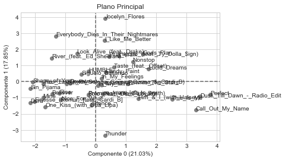

```python
acp.plot_plano_principal()
```

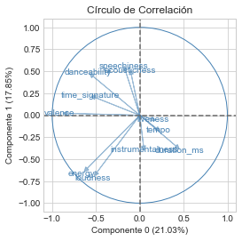

```python
acp.plot_circulo()
```

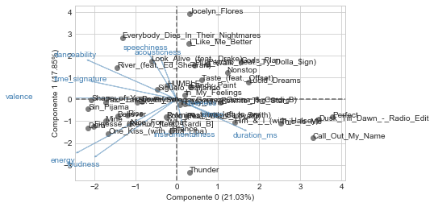

```python
acp.plot_sobreposicion()
```

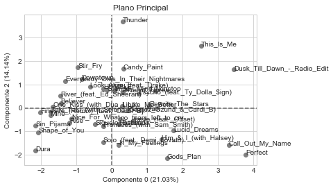

```python
acp.plot_plano_principal(ejes = [0, 2])
```

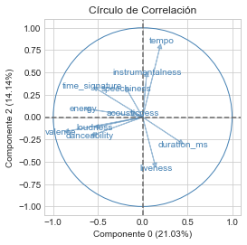

```python
acp.plot_circulo(ejes = [0, 2])
```

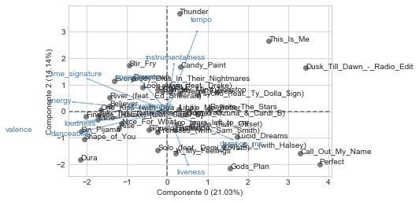

```python
acp.plot_sobreposicion(ejes = [0, 2])
```

### Ahora bien en el plano del ajuste de componentes 1 y 3, la estimacion, explica aun menos variabilidad, el componente 0 aun 21,03%, y el componente 2 un 14,14%. La dispersion de las variables en el circulo de correlacion se vuelve aun mas compleja.

### Viendo el grafico de sobreposicion, tomamos primero In my Feelings, este se encuentra destacando y relacionado mas con liveness e pero poco relacionado con otras variables. Candy Paint se relaciona mas con tempo y instrumentalness, Humble, In my Mind y Havana son canciones mas relacionadas con el promedio de canciones, y se puede relacionar en terminos medios con las siguientes variables.

# Ejercicio 2

## En este ejercicio vamos a usar los datos TablaAffairs.csv

## a) Calcule el resumen numerico, interprete los resultados para una variable.

```python
import os
import pandas as pd
pasada = os.getcwd()
os.chdir("C:/Users/rzamoram/Documents/Machine Learning/Métodos NO Supervisados con Python/Clase 1")
os.getcwd()
ejemplo10 = pd.read_csv("TablaAffairs.csv", delimiter = ';', decimal = ".", header = 0, index_col = 0)
print(ejemplo10.head())
datos = pd.DataFrame(ejemplo10)
```

```
   TiempoInfiel  Genero  Edad  AnnosCasado Hijos  Religioso  Educacion  \
1             0    male  37.0        10.00    no       2.98      17.84
2             0  female  27.0         4.00    no       4.16      13.38
3             0  female  32.0        15.00   yes       0.97      12.69
4             0    male  57.0        15.00   yes       4.53      17.79
5             0    male  22.0         0.75    no       1.66      16.87

   Ocupacion Valoracion
1          7      feliz
2          6      feliz
3          1      feliz
4          6  muy feliz
5          6     neural
```

```python
print(datos.dropna().describe())
```

```
       TiempoInfiel        Edad  AnnosCasado   Religioso   Educacion  \
count    601.000000  601.000000   601.000000  601.000000  601.000000
mean       1.455907   32.487521     8.177696    3.128286   16.185042
std        3.298758    9.288762     5.571303    1.206544    2.427380
min        0.000000   17.500000     0.125000    0.510000    8.890000
25%        0.000000   27.000000     4.000000    2.110000   14.270000
50%        0.000000   32.000000     7.000000    3.200000   16.390000
75%        0.000000   37.000000    15.000000    4.140000   17.860000
max       12.000000   57.000000    15.000000    5.490000   20.500000

        Ocupacion
count  601.000000
mean     4.194676
std      1.819443
min      1.000000
25%      3.000000
50%      5.000000
75%      6.000000
max      7.000000
```

```python
print(datos.describe())
```

```
       TiempoInfiel        Edad  AnnosCasado   Religioso   Educacion  \
count    601.000000  601.000000   601.000000  601.000000  601.000000
mean       1.455907   32.487521     8.177696    3.128286   16.185042
std        3.298758    9.288762     5.571303    1.206544    2.427380
min        0.000000   17.500000     0.125000    0.510000    8.890000
25%        0.000000   27.000000     4.000000    2.110000   14.270000
50%        0.000000   32.000000     7.000000    3.200000   16.390000
75%        0.000000   37.000000    15.000000    4.140000   17.860000
max       12.000000   57.000000    15.000000    5.490000   20.500000

        Ocupacion
count  601.000000
mean     4.194676
std      1.819443
min      1.000000
25%      3.000000
50%      5.000000
75%      6.000000
max      7.000000
```

```python
print(datos.mean(numeric_only=True))
```

```
TiempoInfiel     1.455907
Edad            32.487521
AnnosCasado      8.177696
Religioso        3.128286
Educacion       16.185042
Ocupacion        4.194676
dtype: float64
```

```python
print(datos.std(numeric_only=True))
```

```
TiempoInfiel    3.298758
Edad            9.288762
AnnosCasado     5.571303
Religioso       1.206544
Educacion       2.427380
Ocupacion       1.819443
dtype: float64
```

```python
print(datos.max(numeric_only=True))
```

```
TiempoInfiel    12.00
Edad            57.00
AnnosCasado     15.00
Religioso        5.49
Educacion       20.50
Ocupacion        7.00
dtype: float64
```

### En este caso analizando edad, en este caso es una variable ordinal, promedio de edad muestreado de 32,49 anos, hay 601 casos muestreados. Existe una desviacion estandar de 9,29 anos, lo cual indica en general una amplia variedad de edades, ya que se asume casado encima de 18 anos, El minima de 17,5 anos y 57 anos maximo.

## b) Calcule la matriz de correlaciones

```
              TiempoInfiel      Edad  AnnosCasado  Religioso  Educacion  \
TiempoInfiel      1.000000  0.095237     0.186842  -0.137501  -0.010330
Edad              0.095237  1.000000     0.777546   0.178952   0.130390
AnnosCasado       0.186842  0.777546     1.000000   0.200261   0.030205
Religioso        -0.137501  0.178952     0.200261   1.000000  -0.021423
Educacion        -0.010330  0.130390     0.030205  -0.021423   1.000000
Ocupacion         0.049612  0.166413     0.044592  -0.028387   0.534744

              Ocupacion
TiempoInfiel   0.049612
Edad           0.166413
AnnosCasado    0.044592
Religioso     -0.028387
Educacion      0.534744
Ocupacion      1.000000
```

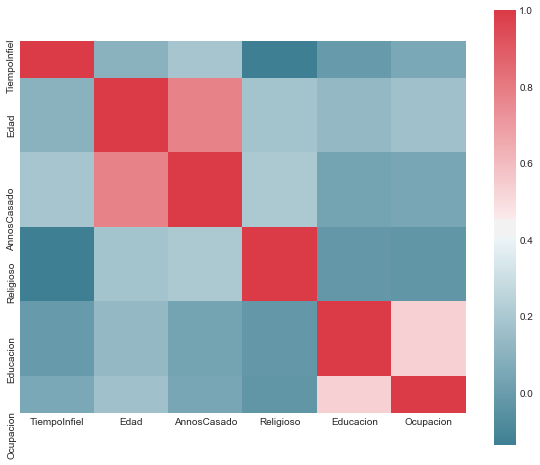

```python
import matplotlib.pyplot as plt
import numpy as np
corr = datos.corr()
print(corr)
f, ax = plt.subplots(figsize=(10, 8))
sns.heatmap(corr, mask=np.zeros_like(corr, dtype=np.bool), cmap=sns.diverging_palette(220, 10, as_cmap=True), square=True, ax=ax)
```

## c) Usando solo las variables numericas efectue un ACP

```python
datos_dummy = pd.get_dummies(datos)
print(datos_dummy.head())
print(datos_dummy.dtypes)
```

```
   TiempoInfiel  Edad  AnnosCasado  Religioso  Educacion  Ocupacion  \
1             0  37.0        10.00       2.98      17.84          7
2             0  27.0         4.00       4.16      13.38          6
3             0  32.0        15.00       0.97      12.69          1
4             0  57.0        15.00       4.53      17.79          6
5             0  22.0         0.75       1.66      16.87          6

   Genero_female  Genero_male  Hijos_no  Hijos_yes  Valoracion_feliz  \
1              0            1         1          0                 1
2              1            0         1          0                 1
3              1            0         0          1                 1
4              0            1         0          1                 0
5              0            1         1          0                 0

   Valoracion_infeliz  Valoracion_muy feliz  Valoracion_muy infeliz  \
1                   0                     0                       0
2                   0                     0                       0
3                   0                     0                       0
4                   0                     1                       0
5                   0                     0                       0

   Valoracion_neural
1                  0
2                  0
3                  0
4                  0
5                  1
TiempoInfiel                int64
Edad                      float64
AnnosCasado               float64
Religioso                 float64
Educacion                 float64
Ocupacion                   int64
Genero_female               uint8
Genero_male                 uint8
Hijos_no                    uint8
Hijos_yes                   uint8
Valoracion_feliz            uint8
Valoracion_infeliz          uint8
Valoracion_muy feliz        uint8
Valoracion_muy infeliz      uint8
Valoracion_neural           uint8
dtype: object
```

```python
acp = ACP(datos_dummy,n_componentes=4)
print(acp.coordenadas_ind.head())
```

```
          0         1         2         3
1  0.001797 -2.662481  1.365868 -0.952568
2  2.027047  0.098395  1.466569 -1.405718
3 -0.296931  2.631486  1.346155 -1.263189
4 -2.476567 -1.253375 -2.556750 -0.082658
5  1.847965 -2.564785  1.258225  0.920318
```

```python
print(acp.cos2_ind.head())
```

```
              0         1         2         3
1  3.273302e-07  0.718815  0.189174  0.092010
2  4.983246e-01  0.001174  0.260849  0.239652
3  8.460901e-03  0.664518  0.173898  0.153123
4  4.304692e-01  0.110256  0.458795  0.000480
5  2.748867e-01  0.529502  0.127433  0.068178
```

```python
print(acp.correlacion_var)
```

```
                               0         1         2         3
AnnosCasado            -0.784062  0.287405 -0.150064  0.024612
Edad                   -0.748467  0.063380 -0.176777  0.026276
Educacion              -0.231068 -0.639095 -0.027203 -0.054436
Genero_female           0.411918  0.804448  0.037588 -0.070336
Genero_male            -0.411918 -0.804448 -0.037588  0.070336
Hijos_no                0.789786 -0.360888  0.168340  0.076195
Hijos_yes              -0.789786  0.360888 -0.168340 -0.076195
Ocupacion              -0.239390 -0.701010  0.042989  0.091457
Religioso              -0.198679  0.076383 -0.417279 -0.257115
TiempoInfiel           -0.222872  0.099661  0.362222  0.565976
Valoracion_feliz       -0.254974 -0.038793  0.602005 -0.713977
Valoracion_infeliz     -0.195625  0.143689  0.216981  0.630085
Valoracion_muy feliz    0.442465 -0.140386 -0.774916  0.070714
Valoracion_muy infeliz -0.087476  0.178557  0.027874  0.206648
Valoracion_neural      -0.057928  0.035428  0.064879  0.191124
```

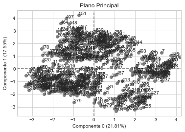

```python
acp.plot_plano_principal()
```

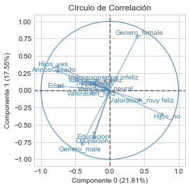

```python
acp.plot_circulo()
```

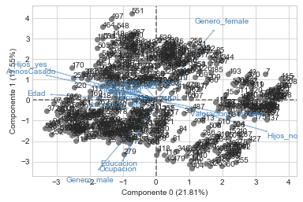

```python
acp.plot_sobreposicion()
```

### En este caso se genera un ACP de 4 componentes. El plano principal de todas las variables muestra que existe una gran dispersion de los datos, pero a su vez el componente 0 solo explica 21,81% de la variabilidad del modelo y el componente 1 solo un 17,55% adicional. Es decir, el modelo no llega a explicar gran parte de la variabilidad en ambos componentes. Asi mismo el circulo de correlacion, muestra la correlacion entre variables de forma visual.

### En el ACP, la correlacion muestra una dificil agrupacion entre variables en cuatro puntos del plano, al menos de forma visual. Parece haber una relacion entre por ejemplo genero_female semuestra como un solo componente educacion, genero_male y ocupacion otro, Valoracion_muyfeliz y hijos_no, un tercer componente. El cuarto componente se desprende del resto.

### El plano de sobre-posicion muestra un plano visual con datos muy dispersos que cabe destacar que se acumulan hacia los cuatro componentes. Cabe senalar que se ven bastante separados los cuatro clusteres

## d) Ahora convierta las variables Genero e Hijos en Codigo Disyuntivo Completo y repita el ACP

```python
# Recodificando la variable usando texto y luego se convierten a variables Dummy
def recodificar(col, nuevo_codigo):
  col_cod = pd.Series(col, copy=True)
  for llave, valor in nuevo_codigo.items():
    col_cod.replace(llave, valor, inplace=True)
  return col_cod

datos["Genero"] = recodificar(datos["Genero"], {'male':1,'female':2})
datos["Hijos"] = recodificar(datos["Hijos"], {'no':1,'yes':2})
print(datos.head())
print(datos.dtypes)
```

```
   TiempoInfiel  Genero  Edad  AnnosCasado  Hijos  Religioso  Educacion  \
1             0       1  37.0        10.00      1       2.98      17.84
2             0       2  27.0         4.00      1       4.16      13.38
3             0       2  32.0        15.00      2       0.97      12.69
4             0       1  57.0        15.00      2       4.53      17.79
5             0       1  22.0         0.75      1       1.66      16.87

   Ocupacion Valoracion
1          7      feliz
2          6      feliz
3          1      feliz
4          6  muy feliz
5          6     neural
TiempoInfiel      int64
Genero            int64
Edad            float64
AnnosCasado     float64
Hijos             int64
Religioso       float64
Educacion       float64
Ocupacion         int64
Valoracion       object
dtype: object
```

```python
# Conviertiendo la variables en Dummy
datos_dummy = pd.get_dummies(datos)
print(datos_dummy.head())
print(datos_dummy.dtypes)
```

```
   TiempoInfiel  Genero  Edad  AnnosCasado  Hijos  Religioso  Educacion  \
1             0       1  37.0        10.00      1       2.98      17.84
2             0       2  27.0         4.00      1       4.16      13.38
3             0       2  32.0        15.00      2       0.97      12.69
4             0       1  57.0        15.00      2       4.53      17.79
5             0       1  22.0         0.75      1       1.66      16.87

   Ocupacion  Valoracion_feliz  Valoracion_infeliz  Valoracion_muy feliz  \
1          7                 1                   0                     0
2          6                 1                   0                     0
3          1                 1                   0                     0
4          6                 0                   0                     1
5          6                 0                   0                     0

   Valoracion_muy infeliz  Valoracion_neural
1                       0                  0
2                       0                  0
3                       0                  0
4                       0                  0
5                       0                  1
TiempoInfiel                int64
Genero                      int64
Edad                      float64
AnnosCasado               float64
Hijos                       int64
Religioso                 float64
Educacion                 float64
Ocupacion                   int64
Valoracion_feliz            uint8
Valoracion_infeliz          uint8
Valoracion_muy feliz        uint8
Valoracion_muy infeliz      uint8
Valoracion_neural           uint8
dtype: object
```

```python
acp = ACP(datos_dummy,n_componentes=4)
print(acp.coordenadas_ind.head())
```

```
          0         1         2         3
1 -0.629714 -2.177193  1.332791 -0.278832
2  1.046993 -0.009638  1.767058 -0.711939
3 -0.383694  2.269008  1.901695 -0.582013
4 -2.115817 -1.286068 -2.429533 -1.389575
5  1.616872 -1.591001  0.733705  1.433501
```

```python
print(acp.cos2_ind.head())
```

```
          0         1         2         3
1  0.056723  0.678059  0.254096  0.011121
2  0.231968  0.000020  0.660756  0.107257
3  0.015914  0.556535  0.390933  0.036617
4  0.320583  0.118444  0.422697  0.138276
5  0.337814  0.327090  0.069561  0.265535
```

```python
print(acp.correlacion_var.head())
```

```
                    0         1         2         3
AnnosCasado -0.844061  0.213623 -0.226251 -0.150776
Edad        -0.814725  0.012013 -0.263805 -0.156654
Educacion   -0.211537 -0.775570 -0.049191  0.042252
Genero       0.298195  0.676003  0.064720 -0.086977
Hijos       -0.670651  0.258316 -0.088330 -0.144303
```

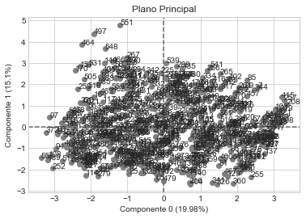

```python
acp.plot_plano_principal()
```

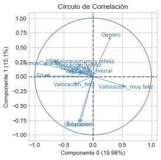

```python
acp.plot_circulo()
```

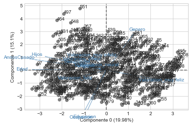

```python
acp.plot_sobreposicion()
```

# Ejercicio 3

## En este ejercicio vamos a realizar un ACP para la tabla SAheart.csv

## a) Efectue un ACP usando solo las variables numericas

```python
import os
import pandas as pd
pasada = os.getcwd()
os.chdir("C:/Users/rzamoram/Documents/Machine Learning/Métodos NO Supervisados con Python/Clase 1")
os.getcwd()
ejemplo10 = pd.read_csv("SAheart.csv", delimiter = ';', decimal = ".", header = 0, index_col = 0)
print(ejemplo10.head())
datos = pd.DataFrame(ejemplo10)
```

```
     tobacco   ldl  adiposity  famhist  typea  obesity  alcohol  age chd
sbp
160    12.00  5.73      23.11  Present     49    25.30    97.20   52  Si
144     0.01  4.41      28.61   Absent     55    28.87     2.06   63  Si
118     0.08  3.48      32.28  Present     52    29.14     3.81   46  No
170     7.50  6.41      38.03  Present     51    31.99    24.26   58  Si
134    13.60  3.50      27.78  Present     60    25.99    57.34   49  Si
```

```python
datos_dummy = pd.get_dummies(datos)
print(datos_dummy.head())
print(datos_dummy.dtypes)
```

```
     tobacco   ldl  adiposity  typea  obesity  alcohol  age  famhist_Absent  \
sbp
160    12.00  5.73      23.11     49    25.30    97.20   52               0
144     0.01  4.41      28.61     55    28.87     2.06   63               1
118     0.08  3.48      32.28     52    29.14     3.81   46               0
170     7.50  6.41      38.03     51    31.99    24.26   58               0
134    13.60  3.50      27.78     60    25.99    57.34   49               0

     famhist_Present  chd_No  chd_Si
sbp
160                1       0       1
144                0       0       1
118                1       1       0
170                1       0       1
134                1       0       1
tobacco            float64
ldl                float64
adiposity          float64
typea                int64
obesity            float64
alcohol            float64
age                  int64
famhist_Absent       uint8
famhist_Present      uint8
chd_No               uint8
chd_Si               uint8
dtype: object
```

```python
acp = ACP(datos_dummy,n_componentes=3)
print(acp.coordenadas_ind.head())
```

```
            0         1         2
sbp
160  2.781854 -1.207537  0.935407
144  1.089841  0.988773  1.505893
118  0.350986 -0.534242 -2.189156
170  3.634969  0.149284 -0.328365
134  2.645603 -1.243362  0.998925
```

```python
print(acp.cos2_ind.head())
```

```
            0         1         2
sbp
160  0.768351  0.144774  0.086875
144  0.267926  0.220537  0.511537
118  0.023686  0.054877  0.921437
170  0.990249  0.001670  0.008081
134  0.733439  0.161998  0.104564
```

```python
print(acp.correlacion_var.head())
```

```
                  0         1         2
adiposity  0.698081  0.532470 -0.297071
age        0.711248  0.287741 -0.015202
alcohol    0.172190  0.006374  0.018202
chd_No    -0.727783  0.196794 -0.602345
chd_Si     0.727783 -0.196794  0.602345
```

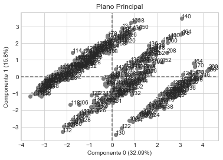

```python
acp.plot_plano_principal()
```

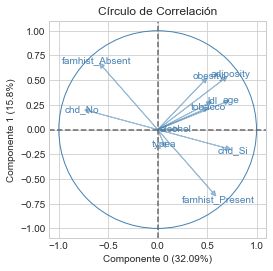

```python
acp.plot_circulo()
```

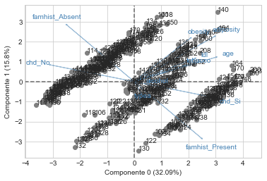

```python
acp.plot_sobreposicion()
```

### En este caso se genera un ACP de 3 componentes, ya que por la tendencia de los datos se puede notar perfectamente que los datos se agrupan en tres clusters en forma de ovoide. El plano principal de todas las variables muestra que existe una gran dispersion de los datos, pero a su vez el componente 0 solo explica 32,09% de la variabilidad del modelo y el componente 1 solo un 15,8% adicional, mejor que en los ejercicios anteriores. Es decir, el modelo no llega a explicar gran parte de la variabilidad en ambos componentes.

### Asi mismo el circulo de correlacion, muestra la correlacion entre variables de forma visual. En el ACP, la correlacion muestra una dificil agrupacion entre variables en tres puntos del plano, al menos de forma visual. Parece haber una relacion entre obesity, age, ldl, tobacco y adiposity. Otro, parece surgir de famhist_Absent y chd_No. Los restantes en otra agrupacion caracteristica.

### El plano de sobre-posicion muestra un plano visual con datos dispersos en tres clusters que cabe destacar que se acumulan hacia los varaiables en tres componentes caracteristicos.

## b) Efectue un ACP usando las variables num´ericas y las variables categoricas

```python
def recodificar(col, nuevo_codigo):
  col_cod = pd.Series(col, copy=True)
  for llave, valor in nuevo_codigo.items():
    col_cod.replace(llave, valor, inplace=True)
  return col_cod

datos["famhist"] = recodificar(datos["famhist"], {'Present':1,'Absent':2})
print(datos.head())
print(datos.dtypes)
# Conviertiendo la variables en Dummy
datos_dummy = pd.get_dummies(datos)
print(datos_dummy.head())
print(datos_dummy.dtypes)
```

```
     tobacco   ldl  adiposity  famhist  typea  obesity  alcohol  age chd
sbp
160    12.00  5.73      23.11        1     49    25.30    97.20   52  Si
144     0.01  4.41      28.61        2     55    28.87     2.06   63  Si
118     0.08  3.48      32.28        1     52    29.14     3.81   46  No
170     7.50  6.41      38.03        1     51    31.99    24.26   58  Si
134    13.60  3.50      27.78        1     60    25.99    57.34   49  Si
tobacco      float64
ldl          float64
adiposity    float64
famhist        int64
typea          int64
obesity      float64
alcohol      float64
age            int64
chd           object
dtype: object
     tobacco   ldl  adiposity  famhist  typea  obesity  alcohol  age  chd_No  \
sbp
160    12.00  5.73      23.11        1     49    25.30    97.20   52       0
144     0.01  4.41      28.61        2     55    28.87     2.06   63       0
118     0.08  3.48      32.28        1     52    29.14     3.81   46       1
170     7.50  6.41      38.03        1     51    31.99    24.26   58       0
134    13.60  3.50      27.78        1     60    25.99    57.34   49       0

     chd_Si
sbp
160       1
144       1
118       0
170       1
134       1
tobacco      float64
ldl          float64
adiposity    float64
famhist        int64
typea          int64
obesity      float64
alcohol      float64
age            int64
chd_No         uint8
chd_Si         uint8
dtype: object
```

```python
acp = ACP(datos_dummy,n_componentes=2)
print(acp.coordenadas_ind.head())
```

```
            0         1
sbp
160  2.457329  1.548752
144  1.534222  0.541597
118 -0.129421 -1.267766
170  3.417849 -0.227290
134  2.319131  1.615711
```

```python
print(acp.cos2_ind.head())
```

```
            0         1
sbp
160  0.715704  0.284296
144  0.889192  0.110808
118  0.010314  0.989686
170  0.995597  0.004403
134  0.673231  0.326769
```

```python
print(acp.correlacion_var.head())
```

```
                  0         1
adiposity  0.747617 -0.546787
age        0.743243 -0.180229
alcohol    0.172214  0.014985
chd_No    -0.741790 -0.608970
chd_Si     0.741790  0.608970
```

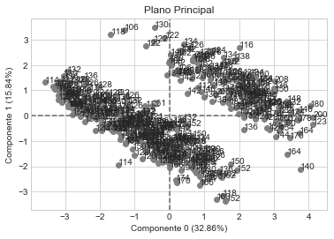

```python
acp.plot_plano_principal()
```

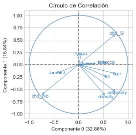

```python
acp.plot_circulo()
```

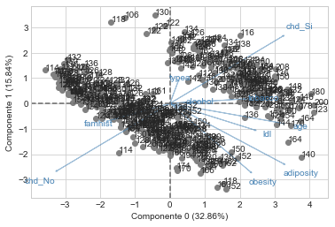

```python
acp.plot_sobreposicion()
```

### En este caso se genera un ACP de 2 componentes, ya que por la tendencia de los datos se puede notar perfectamente que los datos se agrupan en dos clusters en forma de ovoide. El plano principal de todas las variables muestra que existe una gran dispersion de los datos, pero a su vez el componente 0 solo explica 32,86% de la variabilidad del modelo y el componente 1 solo un 15,84% adicional, mejor que en el ejercicio anterior. Es decir, el modelo no llega a explicar gran parte de la variabilidad en ambos componentes, pero en este caso resulta aunque no significativa la mejor en estimacion de variabilidad, si la estimacion con dos componentes se ve optimizada, asi como por consiguiente la interpretacion de resultados.

### Asi mismo el circulo de correlacion, muestra la correlacion entre variables de forma visual. En el ACP, la correlacion muestra una dificil agrupacion entre variables en dos puntos del plano, al menos de forma visual. Existe relacion inversa entre variables en un componente por ejemplo. (chd_si y chd_no)

### El plano de sobre-posicion muestra un plano visual con datos dispersos en dos clusters

# Ejercicio 4

## Programe una clase derivada (que herede) de la clase class ACP

## a) Que sobrecargue el constructor de la clase init para seleccionar variables

```python
import os
import pandas as pd
pasada = os.getcwd()
os.chdir("C:/Users/rzamoram/Documents/Machine Learning/Métodos NO Supervisados con Python/Clase 1")
os.getcwd()
ejemplo10 = pd.read_csv("SpotifyTop2018_40_V2.csv", decimal = ".", header = 0, index_col = 0)
print(ejemplo10.head())
datos = pd.DataFrame(ejemplo10)

import matplotlib.pyplot as plt
from prince import PCA

class ACP:
    def __init__(self, datos, n_componentes = 5):
        self.__datos = datos
        self.__modelo = PCA(n_components = n_componentes).fit(self.__datos)
        self.__correlacion_var = self.__modelo.column_correlations(datos)
        self.__coordenadas_ind = self.__modelo.row_coordinates(datos)
        self.__contribucion_ind = self.__modelo.row_contributions(datos)
        self.__cos2_ind = self.__modelo.row_cosine_similarities(datos)
        self.__var_explicada = [x * 100 for x in self.__modelo.explained_inertia_]
    @property
    def datos(self):
        return self.__datos
    @datos.setter
    def datos(self, datos):
        self.__datos = datos
    @property
    def modelo(self):
        return self.__modelo
    @property
    def correlacion_var(self):
        return self.__correlacion_var
    @property
    def coordenadas_ind(self):
        return self.__coordenadas_ind
    @property
    def contribucion_ind(self):
        return self.__contribucion_ind
    @property
    def cos2_ind(self):
        return self.__cos2_ind
    @property
    def var_explicada(self):
        return self.__var_explicada
        self.__var_explicada = var_explicada
    def plot_plano_principal(self, ejes = [0, 1], ind_labels = True, titulo = 'Plano Principal'):
        x = self.coordenadas_ind[ejes[0]].values
        y = self.coordenadas_ind[ejes[1]].values
        plt.style.use('seaborn-whitegrid')
        plt.scatter(x, y, color = 'gray')
        plt.title(titulo)
        plt.axhline(y = 0, color = 'dimgrey', linestyle = '--')
        plt.axvline(x = 0, color = 'dimgrey', linestyle = '--')
        inercia_x = round(self.var_explicada[ejes[0]], 2)
        inercia_y = round(self.var_explicada[ejes[1]], 2)
        plt.xlabel('Componente ' + str(ejes[0]) + ' (' + str(inercia_x) + '%)')
        plt.ylabel('Componente ' + str(ejes[1]) + ' (' + str(inercia_y) + '%)')
        if ind_labels:
            for i, txt in enumerate(self.coordenadas_ind.index):
                plt.annotate(txt, (x[i], y[i]))
    def plot_circulo(self, ejes = [0, 1], var_labels = True, titulo = 'Círculo de Correlación'):
        cor = self.correlacion_var.iloc[:, ejes].values
        plt.style.use('seaborn-whitegrid')
        c = plt.Circle((0, 0), radius = 1, color = 'steelblue', fill = False)
        plt.gca().add_patch(c)
        plt.axis('scaled')
        plt.title(titulo)
        plt.axhline(y = 0, color = 'dimgrey', linestyle = '--')
        plt.axvline(x = 0, color = 'dimgrey', linestyle = '--')
        inercia_x = round(self.var_explicada[ejes[0]], 2)
        inercia_y = round(self.var_explicada[ejes[1]], 2)
        plt.xlabel('Componente ' + str(ejes[0]) + ' (' + str(inercia_x) + '%)')
        plt.ylabel('Componente ' + str(ejes[1]) + ' (' + str(inercia_y) + '%)')
        for i in range(cor.shape[0]):
            plt.arrow(0, 0, cor[i, 0] * 0.95, cor[i, 1] * 0.95, color = 'steelblue',
                      alpha = 0.5, head_width = 0.05, head_length = 0.05)
            if var_labels:
                plt.text(cor[i, 0] * 1.05, cor[i, 1] * 1.05, self.correlacion_var.index[i],
                         color = 'steelblue', ha = 'center', va = 'center')
    def plot_sobreposicion(self, ejes = [0, 1], ind_labels = True,
                      var_labels = True, titulo = 'Sobreposición Plano-Círculo'):
        x = self.coordenadas_ind[ejes[0]].values
        y = self.coordenadas_ind[ejes[1]].values
        cor = self.correlacion_var.iloc[:, ejes]
        scale = min((max(x) - min(x)/(max(cor[ejes[0]]) - min(cor[ejes[0]]))),
                    (max(y) - min(y)/(max(cor[ejes[1]]) - min(cor[ejes[1]])))) * 0.7
        cor = self.correlacion_var.iloc[:, ejes].values
        plt.style.use('seaborn-whitegrid')
        plt.axhline(y = 0, color = 'dimgrey', linestyle = '--')
        plt.axvline(x = 0, color = 'dimgrey', linestyle = '--')
        inercia_x = round(self.var_explicada[ejes[0]], 2)
        inercia_y = round(self.var_explicada[ejes[1]], 2)
        plt.xlabel('Componente ' + str(ejes[0]) + ' (' + str(inercia_x) + '%)')
        plt.ylabel('Componente ' + str(ejes[1]) + ' (' + str(inercia_y) + '%)')
        plt.scatter(x, y, color = 'gray')
        if ind_labels:
            for i, txt in enumerate(self.coordenadas_ind.index):
                plt.annotate(txt, (x[i], y[i]))
        for i in range(cor.shape[0]):
            plt.arrow(0, 0, cor[i, 0] * scale, cor[i, 1] * scale, color = 'steelblue',
                      alpha = 0.5, head_width = 0.05, head_length = 0.05)
            if var_labels:
                plt.text(cor[i, 0] * scale * 1.15, cor[i, 1] * scale * 1.15,
                         self.correlacion_var.index[i],
                         color = 'steelblue', ha = 'center', va = 'center')
    def plot_plano_principal_sobre(self, ejes = [0, 1], ind_labels = True, titulo = 'Plano Principal'):
        x = self.coordenadas_ind[ejes[0]].values
        y = self.coordenadas_ind[ejes[1]].values
        plt.style.use('seaborn-whitegrid')
        plt.scatter(x, y, color = 'gray')
        plt.title(titulo)
        plt.axhline(y = 0, color = 'dimgrey', linestyle = '--')
        plt.axvline(x = 0, color = 'dimgrey', linestyle = '--')
        inercia_x = round(self.var_explicada[ejes[0]], 2)
        inercia_y = round(self.var_explicada[ejes[1]], 2)
        plt.xlabel('Componente ' + str(ejes[0]) + ' (' + str(inercia_x) + '%)')
        plt.ylabel('Componente ' + str(ejes[1]) + ' (' + str(inercia_y) + '%)')
        if ind_labels:
            for i, txt in enumerate(self.coordenadas_ind.index):
                plt.annotate(txt, (x[i], y[i]))
    def plot_sobreposicion_sobre(self, ejes = [0, 1], ind_labels = True,var_labels = True, titulo = 'Sobreposición Plano-Círculo'):
        x = self.coordenadas_ind[ejes[0]].values
        y = self.coordenadas_ind[ejes[1]].values
        cor = self.correlacion_var.iloc[:, ejes]
        scale = min((max(x) - min(x)/(max(cor[ejes[0]]) - min(cor[ejes[0]]))),
                    (max(y) - min(y)/(max(cor[ejes[1]]) - min(cor[ejes[1]])))) * 0.7
        cor = self.correlacion_var.iloc[:, ejes].values
        plt.style.use('seaborn-whitegrid')
        plt.axhline(y = 0, color = 'dimgrey', linestyle = '--')
        plt.axvline(x = 0, color = 'dimgrey', linestyle = '--')
        inercia_x = round(self.var_explicada[ejes[0]], 2)
        inercia_y = round(self.var_explicada[ejes[1]], 2)
        plt.xlabel('Componente ' + str(ejes[0]) + ' (' + str(inercia_x) + '%)')
        plt.ylabel('Componente ' + str(ejes[1]) + ' (' + str(inercia_y) + '%)')
        plt.scatter(x, y, color = 'gray')
        if ind_labels:
            for i, txt in enumerate(self.coordenadas_ind.index):
                plt.annotate(txt, (x[i], y[i]))
        for i in range(cor.shape[0]):
            plt.arrow(0, 0, cor[i, 0] * scale, cor[i, 1] * scale, color = 'steelblue',
                      alpha = 0.5, head_width = 0.05, head_length = 0.05)
            if var_labels:
                plt.text(cor[i, 0] * scale * 1.15, cor[i, 1] * scale * 1.15,
                         self.correlacion_var.index[i],
                         color = 'steelblue', ha = 'center', va = 'center')


class ACP_sobrecaragado(ACP):
    def __init__(self, datos, n_componentes = 3,colum_eliminar=[]):
        self.__datos = datos
        self.__colum_eliminar = colum_eliminar
        for col in self.__colum_eliminar:
            del self.__datos[col]
        self.__modelo = PCA(n_components = n_componentes).fit(self.__datos)
        self.__correlacion_var = self.__modelo.column_correlations(datos)
        self.__coordenadas_ind = self.__modelo.row_coordinates(datos)
        self.__contribucion_ind = self.__modelo.row_contributions(datos)
        self.__cos2_ind = self.__modelo.row_cosine_similarities(datos)
        self.__var_explicada = [x * 100 for x in self.__modelo.explained_inertia_]
    @property
    def vector(self):
       return self.__vector
    @vector.setter
    def vector(self, nuevo):
       self.__vector = nuevo
    @property
    def datos(self):
        return self.__datos
    @datos.setter
    def datos(self, nuevo):
        self.__datos = nuevo
```

```
                          danceability  energy  loudness  speechiness  \
Dura                             0.791   0.848    -3.456       0.0506
Plug_Walk                        0.876   0.519    -6.531       0.1430
Silence                          0.520   0.761    -3.093       0.0853
Solo_(feat._Demi_Lovato)         0.737   0.636    -4.546       0.0437
Sin_Pijama                       0.791   0.745    -3.695       0.0464

                          acousticness  instrumentalness  liveness  valence  \
Dura                            0.1830          0.000000     0.409    0.828
Plug_Walk                       0.2020          0.000000     0.108    0.158
Silence                         0.2560          0.000005     0.170    0.286
Solo_(feat._Demi_Lovato)        0.0441          0.000067     0.350    0.565
Sin_Pijama                      0.3540          0.000029     0.104    0.820

                            tempo  duration_ms  time_signature
Dura                       95.000       200480               4
Plug_Walk                  94.981       175230               4
Silence                   141.971       180823               4
Solo_(feat._Demi_Lovato)  105.005       222653               4
Sin_Pijama                 94.014       188560               4
```

## b) Que sobrecargue los metodos plot plano principal y plot sobreposicion

```python
class ACP_princ_sobre_sobracaragado(ACP):
    def plot_plano_principal_sobre(self, ejes = [0, 1], ind_labels = True, titulo = 'Plano Principal'):
        x = self.coordenadas_ind[ejes[0]].values
        y = self.coordenadas_ind[ejes[1]].values
        plt.style.use('seaborn-whitegrid')
        plt.scatter(x, y, color = 'gray')
        plt.title(titulo)
        plt.axhline(y = 0, color = 'dimgrey', linestyle = '--')
        plt.axvline(x = 0, color = 'dimgrey', linestyle = '--')
        inercia_x = round(self.var_explicada[ejes[0]], 2)
        inercia_y = round(self.var_explicada[ejes[1]], 2)
        plt.xlabel('Componente ' + str(ejes[0]) + ' (' + str(inercia_x) + '%)')
        plt.ylabel('Componente ' + str(ejes[1]) + ' (' + str(inercia_y) + '%)')
        if ind_labels:
            for i, txt in enumerate(self.coordenadas_ind.index):
                plt.annotate(txt, (x[i], y[i]))
    def plot_sobreposicion_sobre(self, ejes = [0, 1], ind_labels = True,
                      var_labels = True, titulo = 'Sobreposición Plano-Círculo'):
        x = self.coordenadas_ind[ejes[0]].values
        y = self.coordenadas_ind[ejes[1]].values
        cor = self.correlacion_var.iloc[:, ejes]
        scale = min((max(x) - min(x)/(max(cor[ejes[0]]) - min(cor[ejes[0]]))),
                    (max(y) - min(y)/(max(cor[ejes[1]]) - min(cor[ejes[1]])))) * 0.7
        cor = self.correlacion_var.iloc[:, ejes].values
        plt.style.use('seaborn-whitegrid')
        plt.axhline(y = 0, color = 'dimgrey', linestyle = '--')
        plt.axvline(x = 0, color = 'dimgrey', linestyle = '--')
        inercia_x = round(self.var_explicada[ejes[0]], 2)
        inercia_y = round(self.var_explicada[ejes[1]], 2)
        plt.xlabel('Componente ' + str(ejes[0]) + ' (' + str(inercia_x) + '%)')
        plt.ylabel('Componente ' + str(ejes[1]) + ' (' + str(inercia_y) + '%)')
        plt.scatter(x, y, color = 'gray')
        if ind_labels:
            for i, txt in enumerate(self.coordenadas_ind.index):
                plt.annotate(txt, (x[i], y[i]))
        for i in range(cor.shape[0]):
            plt.arrow(0, 0, cor[i, 0] * scale, cor[i, 1] * scale, color = 'steelblue',
                      alpha = 0.5, head_width = 0.05, head_length = 0.05)
            if var_labels:
                plt.text(cor[i, 0] * scale * 1.15, cor[i, 1] * scale * 1.15,
                         self.correlacion_var.index[i],
                         color = 'steelblue', ha = 'center', va = 'center')
```

```python
acp = ACP(datos,n_componentes=3)
print(acp.coordenadas_ind.head())
print(acp.cos2_ind.head())
print(acp.correlacion_var.head())
```

```
                                 0         1         2
Dura                     -2.158016 -1.298592 -1.826558
Plug_Walk                 0.440042  1.566524 -0.112412
Silence                  -0.129625 -1.455367  0.746510
Solo_(feat._Demi_Lovato) -0.238512 -0.854628 -1.454895
Sin_Pijama               -2.146927 -0.437891 -0.756985
                                 0         1         2
Dura                      0.481114  0.174214  0.344672
Plug_Walk                 0.072789  0.922461  0.004750
Silence                   0.006241  0.786760  0.206999
Solo_(feat._Demi_Lovato)  0.019590  0.251512  0.728899
Sin_Pijama                0.857692  0.035680  0.106628
                         0         1         2
acousticness     -0.102040  0.489755  0.045054
danceability     -0.561408  0.466725 -0.201905
duration_ms       0.435534 -0.369733 -0.287193
energy           -0.630813 -0.636606  0.093463
instrumentalness  0.044901 -0.367711  0.479720
```

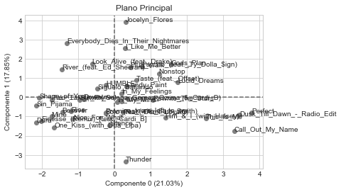

```python
acp.plot_plano_principal_sobre()
```

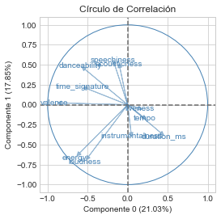

```python
acp.plot_circulo()
```

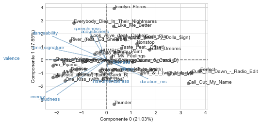

```python
acp.plot_sobreposicion_sobre()
```